# Do Heart Disease Mortality Rates Differ When NASSA Prescription Trends Increase?

B220774

2024-11-29

#### **Introduction**

###### Mental health and heart disease are prominent public health challenges within Scotland. The recent 2022 census revealed that the percentage of individuals reporting mental health conditions, conditions that affect your well-being, increased from 4.4% in 2011 to a staggering 11.3%, denoting the greatest change across all health categories “Scotland’s Census 2022 - Health, Disability and Unpaid Care” (n.d.). Heart disease describes the range of conditions impeding heart activity and structure, with coronary heart disease occurring most frequently. Since the early 2000s, cardiovascular disease mortality has reduced, however records depict a recent incline McColgan, Sandeman, and Brady (2021). The study Correll et al. (2017) found that individuals with severe mental illness, including schizophrenia, bipolar disorder and sever depression, demonstrated higher risk for cardiovascular disease resulting in premature death. Antidepressants treat multiple mental health conditions, however, the noradrenergic and specific serotonergic antidepressant (NASSA) Mitrazapine is used in the UK as a follow-up treatment if first-line SSRIs fail to work “Overview - Antidepressants” (2021). Therefore, prescription trends can offer valuable insights into depression trends. This assessment aims to explore the intersection of NASSA usage and heart disease mortality in Scotland by visualising trends across health boards and age groups. It initially highlights that general antidepressant prescriptions have risen while in-patient mental health admissions reduced. Additionally, that mortality rates are increasing over time, with variations in NASSA usage across health board regions potentially correlating with increased death rates. Without conducting analysis, this assessment presents a cohesive and detailed overview of the data, offering foundation for future exploration of these critical public health issues.

#### **Load all packages**

```r
# All necessary packages are loaded for data
# import (including csv and shapefiles), data
# wrangling and plotting
library(tidyverse)  # Manipulating and visualising data
library(janitor)  # Cleaning and standardising data
library(gt)  # Pretty tables
library(here)  # File path finder within project
library(dplyr)  # Additional data manipulation
library(ggtext)  # Nice text rendering in ggplot2, which is in tidyverse package
library(scales)  # Scale functions used in visualisation of data
library(ggthemes)  # Provides additional ggplot2 themes
library(ggrepel)  # Repels text and labels for ggplot2
library(sf)  # Used for spatial mapping
library(glue)  # Interpreting string literals
```

#### **Mental Health In-Patient Admissions and Antidepressant Prescription Trends 2015-2023**

##### Mental Health In-Patient Admission Cases Data Preparation

###### The increase in mental health cases in Scotland is accommodated by increased community-based care which includes more prescriptions of antidepressants like Metrazipine, accompanied by a decrease in the in-patient admissions for mental health cases. The following plot demonstrates the trends of antidepressant prescriptions and the inpatient admissions in Scotland between 2015 and 2023. *Note that financial year is represented by the second year within the timeframe.*

```r
### Data Import

# First the open data csv file is read in using
# tidyverse, a hyperlink sourcing the data is
# included to ensure information is up-to-date
Mental_health_total <- read_csv("https://www.opendata.nhs.scot/dataset/4ace86c2-2c0f-4620-b544-932148c2c4d3/resource/7e99efb9-2d73-46e1-bdce-59b00ed20a0f/download/20231212-mental-health-inpatient-activity-health-board-trend.csv") %>%
    clean_names()  # Part of the janitor library, this ensures names of objects are standardised e.g. conversion to lowercase
```

```r
### Data Wrangling

#Next Data is tidied, changing the format
Filtered_MH_total <- Mental_health_total %>%

#The SMR04 code in the 'dataset' column represents Mental Health case Data in Scotland. Filter for this and the years following 2015
  filter(dataset == "SMR04", financial_year >="2014/15") %>%
#This step renders 'financial_year' column numeric for data visualisation through plots, representation of quantitative data. 'sub()' substitutes characters before and including "/" with "20", then converted to numeric format
   mutate(financial_year = as.numeric(sub(".*/", "20", financial_year))) %>%
  select(Year=financial_year, Admissions=number_of_admissions) %>%  # Select required columns for plotting and rename for easy plotting
  group_by(Year) %>%
  summarise(MeanAdmissions = mean(Admissions, na.rm = TRUE)) # Calculate mean admissions per year for standarised measure over time
```

##### Antidepressant Data Preparation

###### In this next section, the antidepressant data is imported and wrangled before the combined plot can be created. The antidepressants selected include; Mirtazapine, a noradrenaline and specific serotonergic antidepressant (NASSA), Fluoxetine, a selective serotonin reuptake inhibitors (SSRI), Venlafaxine, a serotonin-noradrenaline reuptake inhibitors (SNRIs) and Amitriptyline, a tricyclic antidepressants (TCAs).

```r
### Data Import

#To import antidepressant prescription information from 2015 to 2023, dataset csv files of the months October, November, December, are downloaded from https://www.opendata.nhs.scot/dataset/prescriptions-in-the-community and added to the folder named "WinterDrugs2015-2023". This is to ensure the time frame of data collected was maximised. Prescription data for 2015 was only available during these months.

# All CSV files listed in the specified directory
ADFiles <- list.files(here("docs","WinterDrugs2015-2023"), pattern = "csv")

# Function defined to read and process each CSV file cohesively
ReadADFiles <- function(file_name) {
  # Extract the year from the file name using lubridate package in tidyverse. This enables plotting with Year as a variable
  year <- str_extract(file_name, "\\d{4}") %>% as.numeric()
  # Read the CSV file, process the data add year column
  data <- read_csv(here("docs","WinterDrugs2015-2023", file_name), show_col_types = FALSE,  col_types = cols(.default = "c")) %>% # Convert all columns to character type to avoid warnings due to inconsistent data types
    mutate(Year = year, PaidQuantity = as.numeric(PaidQuantity)) %>% # Specifically convert paid quantity to numeric format because the data contains numbers, allows for mathematical operations (e.g sum(), mean())
#Filter for specific antidepressants
    filter(str_detect(BNFItemDescription, "MIRTAZAPINE|FLUOXETINE|VENLAFAXINE|AMITRIPTYLINE"),) %>%
    return(data)
}
# This applies the ReadADFiles function to all the CSV files and combines the results, the large amount of data
ADs_Df <- ADFiles %>%
  map_dfr(ReadADFiles)
```

```r
### Data Wrangling

# The data is cleaned again using janitor, and transformed
Clean_ADs_Df <- ADs_Df %>%
# HBT2014 and HBT columns are combined into a new column called HB, prioritising data from the HBT column as this represents the most recent datasets
  mutate(HB = coalesce(HBT, HBT2014),
#Antidepressants are categorised based on BNFItemDescription which is the British National Formulary information on medicines administered in the United Kingdom.
         Antidepressant = case_when(
             str_detect(BNFItemDescription, "MIRTAZAPINE") ~ "Mirtazapine(NASSA)",
             str_detect(BNFItemDescription, "FLUOXETINE") ~ "Fluoxetine(SSRI)",
             str_detect(BNFItemDescription, "VENLAFAXINE") ~ "Venlafaxine(SNRI)",
             str_detect(BNFItemDescription, "AMITRIPTYLINE") ~ "Amitriptyline(TCA)",
             TRUE ~ NA_character_  # Leave as NA if it doesn't match any MH Drug
           )) %>%  # Create 'hb' from HBT2014 or hbt
  select(-HBT2014, -HBT, HB, Year, PaidQuantity) %>% # select only relevant columns
  filter(!is.na(PaidQuantity)) # ensure there are no "NA" cells in the "PaidQuantity" column which is important in preventing inaccuracies in calculations or summaries, this could also lead to incomplete or misleading visualisations
```

##### Healthboard Names Data Preparation

###### This data is imported so health board codes can be represented by names for easiness and tidiness.

```r
### Data Import

# Hyperlink to ensure efficiency in import and that the data is up-to-date
HBName_Data <- read_csv("https://www.opendata.nhs.scot/dataset/9f942fdb-e59e-44f5-b534-d6e17229cc7b/resource/652ff726-e676-4a20-abda-435b98dd7bdc/download/hb14_hb19.csv") %>%
  clean_names()


### Data Wrangling

# Join the health board names with antidepressant data frame using health board code depicted in concatenation
ADs_HBNames <- full_join(Clean_ADs_Df, HBName_Data, by = c("HB" = "hb")) %>%
  rename(Healthboard = hb_name,
         Code = HB,
         Count = PaidQuantity)%>% # Rename for clarity
  select(Year, Count, Healthboard, Code, Antidepressant) #Select desired columns for plotting
```

##### Combined Plot Visualisation

###### Data is prepared and tidied, ready for visualising in a combined plot. This line and bar plot demonstrate the trend in in-Patient admission cases and antidepressant prescription respectively, from 2015-2023, observe change in antidepressant usage and community-based care.

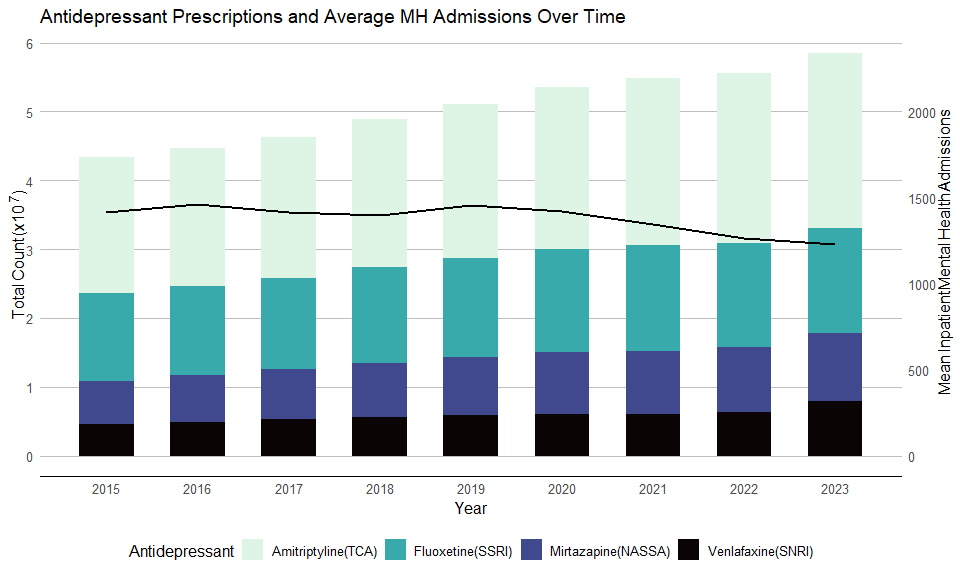

```r
scaling <- 400 #The scaling factor is used to so antidepressant count and in-patient admissions can be displayed on the same plot, normalising the different scales and obtained through trial and error to obtain appropriate scaling. Start by dividing the maximum values of each scale.


### Data Visualisation

Combined_plot <- Combined_data %>%
  group_by(Year, Antidepressant, MeanAdmissions) %>% #
  summarise(Total_Count = sum(Count, na.rm = TRUE)) %>% # Aggregate data using dplyr to calculate Total_Count as the sum of Count, ignoring NA values for accuracy. This is grouped by Year, Antidepressant and MeanAdmissions to ensure they are included in plot formation
#Plot is created for visualisation
  ggplot(aes(x=Year))+
# Stacked bar plot for antipressant Total_Count by year, scaled down for better visualisation
  geom_col(aes(y=Total_Count/1e7, fill=Antidepressant), width = 0.6) +
# Line plot for in-Patient Mean admissions, scaled for comparison
  geom_line(aes(y=MeanAdmissions/scaling), color="black", size=1) +
#Y axis is customised with labels and breaks
  scale_y_continuous(labels = scales::comma, breaks = scales::pretty_breaks(n = 5),
                     name = "\ Total Count (x10 <sup>7</sup>)", #To ensure reader understands data is scaled down, the <sup> HTML tag creates superscript text.
                     sec.axis = sec_axis(~.*scaling, name = "Mean Inpatient Mental Health Admissions")) + # This creates the secondary axis on the right side of the plot.'~' indicates a formula is defined for transformation, '.' represents primary y-axis values. '*' applies scaling factor
  labs(title = "Antidepressant Prescriptions and Average MH Admissions Over Time", x = "Year", fill = "Antidepressant")+
  scale_x_continuous(labels = waiver(), breaks = seq(min(ADs_HBNames$Year), max(ADs_HBNames$Year), by = 1))+
  scale_fill_viridis_d(option = "mako", direction = -1)+ # Use a viridis color scale for better visibility
  theme_hc()+ #Adds a predefined theme for consistent aesthetics
  theme(axis.title.y = element_textbox_simple(width = NULL, orientation = 'left-rotated'), panel.grid.major.x = element_blank(), axis.line.y = element_blank(), axis.line = element_line(size=.3, color='black'), panel.grid.major.y = element_line(colour = "grey", size =0.6), axis.ticks = element_blank()) # Theme elements customized for better presentation


### View Plot
Combined_plot
```

##### Summary

###### In this section, heart disease mortality data is obtained from the same website as the prescriptions in the community: https://www.opendata.nhs.scot/dataset/scottish-heart-disease-statistics. Data is visualised to view the change in the rate of heart disease deaths and what differences occur amoung age groups, during the same period of time antidepressant usage increases.

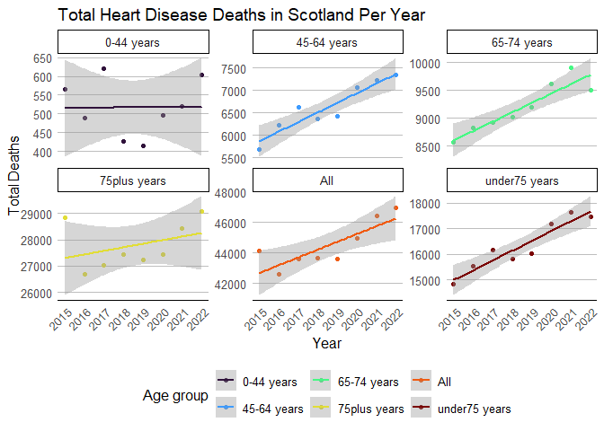

```r
### Data Visualisation

# Plot is created to visualise heart disease deaths per year, grouped by age group to see if there is a change in rate
HD_Plot <- filtered_HD_total %>%
  mutate(age_group = as.factor(age_group)) %>% # Convert age_group to a factor to ensure 'dplyr' treats it as categorical data
  ggplot(aes(x=year, y=total_deaths, group = age_group, colour = age_group))+
  geom_point()+ # Adds points for each observation
  geom_smooth(method=lm)+ # Adds a linear model smooth line to visualize trends
  facet_wrap(~age_group, nrow = 2, scales ="free_y")+
  scale_x_continuous(breaks = function(x) seq(floor(min(x)), ceiling(max(x)), by = 1))+ #Create seprate panels for each age group with free y-scales to identify trends that may be obscured when plot is combined as different age groups have different total death ranges
# Use viridis for discrete colour scale of lines,  'turbo' colour option instead of 'mako' for distinguishable viewing
  scale_color_viridis_d(name = "Age group", option = "turbo") +
  labs(title = "Total Heart Disease Deaths in Scotland Per Year", x = "Year", y = "Total Deaths")+
  theme_hc()+
# Customisations for better representation
  theme(
    axis.title.y = element_textbox_simple(width = NULL, orientation = 'left-rotated'),
    panel.grid.major.x = element_blank(),
    axis.line.y = element_blank(),
    axis.line = element_line(size=.3, color='black'),
    panel.grid.major.y = element_line(colour = "grey", size =0.6),
    axis.ticks = element_blank(),
    axis.text.x = element_text(angle = 45, hjust = 1), # Rotate X-axis for readability
#Customise facet label for aesthetics
    strip.background = element_rect(colour = "black", fill = "white", size=0.2, linetype ="solid"),
strip.text = element_text(size = 10))

#View Plot
HD_Plot
```

##### Summary

###### General increase in most age groups, least in 0-44 years. Observation shows 45-64 years had greatest total deaths increase between 2015 and 2022.

#### **Map of Healthboards by Mitrazipine Prescription Per Person in 2019**

```r
### Data Import

# Population data downloaded from (https://statistics.ukdataservice.ac.uk/dataset/scotland-s-census-2022-uv302b-general-health-by-age-6-groups/resource/ff57700c-fc01-418e-bcd3-a8f5f3c69ee1) and only represents values recorded in 2019
population_data <- read_csv(here("docs", "UV103_age_health_board_census.csv"), skip = 10) %>%
# Rename columns for clarity and tidiness
  rename(hb_name = "Health Board Area 2019",
         hb_population = Count) %>%
# Filter the data so that we get the population of the entire health board
  filter(Age == "All people" & Sex == "All people") %>%
  select(hb_name, hb_population) %>% # Select only the relevant columns
  # Change health board names so they match the prescription data
  mutate(hb_name = paste("NHS", hb_name))


# Prepare mirtazapine data from orginal antidepressant dataframe, filtering for results in 2019 to coincide with population and shapefile data
Mirtazapine_per_head <- ADs_HBNames %>%
  filter(Antidepressant == "Mirtazapine(NASSA)",
         Year == "2019") %>%
  select(-Antidepressant, -Year) %>% # Deselect as they are now irrelevant, only one variable present
  left_join(population_data, by = c("Healthboard" = "hb_name")) %>% #Join with population data to get health board populations
  group_by(Healthboard, Code) %>%  # Group by health board and healthboard code for summarisation and further manipulation
  summarise(
    TotalCount = sum(Count, na.rm = TRUE),  # Total quantity per health board
    Ratio = TotalCount / first(hb_population),    # Calculate ratio
    .groups = "drop"  # Drop grouping after summarising
  ) %>%
  select(Healthboard, Ratio, Code) # Select relevant columns for plotting
```

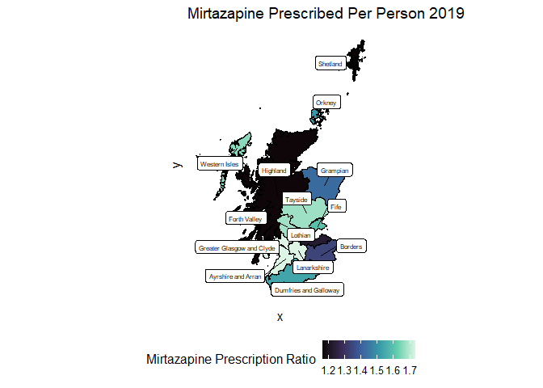

```r
### Data Wrangling

# The Mirtrazapine prescription data is joined with health board shapes, full join performed to include all healthboards and filter out any with missing names
# This highlights why health board code was kept as shapefile data does not have health board names
Mirtazapine_shape <- full_join(HB_shape, Mirtazapine_per_head, by = c("HBCode" = "Code")) %>%
  filter(!is.na(HBName))
#GG spatial plot created to show the density of prescriptions per person and how this varies amoungst health boards

### Data Visualisation
Spatial_Plot <- Mirtazapine_shape %>%
  ggplot(aes(fill = Ratio)) +  # Map fill color to the prescription ratio
  geom_sf(colour = "black", linewidth = 0.2) + #Borders drawn with black lines
  geom_label_repel(aes(label = HBName, geometry = geometry),
                   stat = "sf_coordinates", size = 2.1, color = "black", fill = "white",
                   box.padding = 0.5, nudge_x = 0.1,    # Nudge labels to the right
                   nudge_y = 0.1, max.overlaps = 13) +
  # Labels added to view health board names in their corresponding locations on the map, in accordance with prescription data availability
  scale_fill_viridis_c(name = "Mirtazapine Prescription Ratio", option = "mako") + # Consistent, improved color scale  visibility
  theme_hc() + # Consistent theme as previous plots
  labs(title = "Mirtazapine Prescribed Per Person 2019")+ #Add plot title
  theme(panel.grid = element_blank(), axis.ticks = element_blank(), axis.text = element_blank(), axis.title = element_blank())  # Remove grid lines present

#View Map Plot
Spatial_Plot
```

#### **Table of heart disease differences when Mirtazapine prescription is high versus low**

###### It is interesting to compare heart disease mortality rates between ‘NHS Ayrshire and Arran’ with high Mitrazapine prescription per person and ‘NHS Highland’ with low rates. Both health boards have similar populations, relevant for comparison. The accompanying gt table will focus on the 45-64 age group, as they experienced greatest death increase.

```r
### Data Wrangling

# Heart disease mortality data is prepared for analysis
HD_Table_Prep <- HeartD_mortality %>%
  left_join(HBName_Data, by = c("hbr" = "hb")) %>% # Adds readable health board names as only codes exist currently
  left_join(population_data, by = "hb_name") %>% # populations added to calculate rates and understand the context of mortality numbers, for calculating prescriptions per person
  filter(year == "2019", age_group == "45-64 years", hb_name %in% c("NHS Highland", "NHS Ayrshire and Arran"), sex != "All") %>% # focus on 2019 as population data represents this year, filter for appropriate values and exclude aggregated data for both sexes to enable separate visualisation
  select(Sex = sex, Diagnosis = diagnosis, NumberOfDeaths=number_of_deaths, CrudeRate=crude_rate, EASR=easr, Population=hb_population, Healthboard=hb_name)# relevant columns selected

### Data Visualisation

#For the table subtitle, the healthboard names are extracted and stored as values
Health_Board <- HD_Table_Prep %>%
   filter(Healthboard %in% c("NHS Highland", "NHS Ayrshire and Arran")) %>%
   distinct(Healthboard) %>%
   pull(Healthboard)

#Create the table using the gt package
HD_Table <- HD_Table_Prep %>%
  group_by(Healthboard, Population) %>%
  gt() %>%
  #Diagnosis and Sex columns reorded to the start for better readability
  cols_move_to_start(columns = c(Diagnosis, Sex)) %>%
  #Healthboard moved after Number of Deaths
  cols_move(columns = Sex, after = Diagnosis) %>%
  #Rename columns for clarity
  cols_label(Healthboard = "Health Board",
             NumberOfDeaths = "Number of Deaths",
             CrudeRate = "Crude Rate",
             EASR = "European Age-Sex Standardised Rate") %>%
   fmt_percent(columns = c(CrudeRate, EASR), decimals = 0, scale_value = FALSE) %>% #Format percentage columns
 cols_align(align = "center", columns = NumberOfDeaths) %>% #center-align the 'Number of Deaths' column
  summary_rows(columns = c(NumberOfDeaths, CrudeRate, EASR),
               fns = list("Average" = ~mean(., na.rm = TRUE)), #Summary rows added with averages
               fmt = list(~ fmt_number(., decimals = 2))) %>%
  # Add a title and subtitle
   tab_header(
       title = "Heart Disease Mortality in 2019 in Adults Aged 45-65 years",

  # Glue package can be added for the subtitle, and paste the unique values of health board. md() for Markdown formatting can also be utilised. The HTML span tag is used with inline CSS to colour the word 'Population' in red
       subtitle = md(glue("Data from {paste(Health_Board, collapse = ' and ')} (**<span style='color: red;'>Population</span>**)"))) %>% #
  # Tab_spanner used to add a title specifically to the columns 'CrudeRate' and 'EASR'.
  tab_spanner(label = "Rate per 100k population", columns = c(CrudeRate, EASR)) %>%
  tab_style(style = cell_text(color = "red"), locations = cells_row_groups(groups = everything()))%>%
  tab_options(., container.width = 700, container.height = 200) # for plot display size

#View gt Table
HD_Table
```

Data from NHS Ayrshire and Arran and NHS Highland (**Population**)

|  | Diagnosis | Sex | Number of Deaths | Rate per 100k population Crude Rate | Rate per 100k population European Age-Sex Standardised Rate |
| --- | --- | --- | --- | --- | --- |
| NHS Ayrshire and Arran - 365256 |  |  |  |  |  |
|  | Coronary Heart Disease | Males | 66 | 128% | 123% |
|  | Coronary Heart Disease | Females | 21 | 37% | 35% |
|  | Heart Attack | Males | 45 | 88% | 84% |
|  | Heart Attack | Females | 16 | 28% | 27% |
|  | Heart Failure | Males | 0 | 0% | 0% |
|  | Heart Failure | Females | 0 | 0% | 0% |
| Average | — | — | 24.67 | 46.79 | 44.87 |
| NHS Highland - 321321 |  |  |  |  |  |
|  | Coronary Heart Disease | Males | 48 | 104% | 101% |
|  | Coronary Heart Disease | Females | 15 | 30% | 30% |
|  | Heart Attack | Males | 22 | 48% | 46% |
|  | Heart Attack | Females | 6 | 12% | 12% |
|  | Heart Failure | Males | 0 | 0% | 0% |
|  | Heart Failure | Females | 1 | 2% | 2% |
| Average | — | — | 15.33 | 32.75 | 31.68 |

#### **Discussion**

###### From the GT table, it’s evident that NHS Ayrshire and Arran reports the highest average combined number of heart disease, coinciding with higher Mitrazapine prescription per person rates. Additionally, the data indicates that men are significantly more likely to die from cardiovascular complications, potentially due to hormonal fluctuations and poor lifestyle factors McColgan, Sandeman, and Brady (2021). Coronary heart disease causes the majority of deaths while heart failure contributes the least. Visualisations further reveal a notable rise in antidepressant prescriptions over time, including the NASSA Mirtazapine, accompanied by declining inpatient mental health admissions. This suggests a shift towards community-based care, however, the concurrent increase in heart disease mortality raises questions about potential connections between antidepressant usage indications and cardiovascular outcomes. For example whether more prescription indicates more mental healthcases and this impact on heart health. Regional disparities in prescription trends highlight the importance of regarding mental health and cardiovascular maladies. While these patterns are intriguing, it is essential to recognize that causation cannot directly be inferred as additional factors including socioeconomic status, comorbidities, and post-COVID-19 stressors may potentially contribute to observed trends. The findings support studies that the heart disease mortality risk for individuals with severe mental illness is elevated, demonstrating the need for holistic healthcare strategies that address mental health alongside cardiovascular health. Severe mental illness can biologically impact the cardiovascular system via chronic inflammation with coagulation abnormalities, autonomic nervous system imbalance, HPA axis dysregulation, and metabolic disturbances. These pathologies, compounded by behavioral and systemic factors, excacerbate heart disease and mortality rates in diagnosed individuals Correll et al. (2017). Therefore, early intervention and integrated care interconnectedly addressing mental and physical health are essential for improving population health outcomes in Scotland. In conclcusion, to relay the assessment question, heart disease mortality rates do differ as NASSA prescription increases, there has been an identifiable increase, but it’s also important to consider existing confounding contributors.

##### **ChatGPT Declaration**

###### I used ChatGPT as aid to complete this assessment. I used it to help create the ReadADFiles function for parsing all datasets, to ensure I selected the correct and relevant variables. I also used it to explain errors when creating plots, which guided me in the right direction to improve them effectively.

Correll, Christoph U., Marco Solmi, Nicola Veronese, Beatrice Bortolato, Stella Rosson, Paolo Santonastaso, Nita Thapa-Chhetri, et al. 2017. “Prevalence, Incidence and Mortality from Cardiovascular Disease in Patients with Pooled and Specific Severe Mental Illness: A Large-Scale Meta-Analysis of 3,211,768 Patients and 113,383,368 Controls.” *World Psychiatry* 16 (2): 163–80. https://doi.org/10.1002/wps.20420.

McColgan, David, Dennis Sandeman, and Adrian J B Brady. 2021. “A National Heart Disease Strategy for Scotland: The BHF Proposal to Government.” *The British Journal of Cardiology* 28 (2): 25. https://doi.org/10.5837/bjc.2021.025.

“Overview - Antidepressants.” 2021. *Nhs.uk*. https://www.nhs.uk/mental-health/talking-therapies-medicine-treatments/medicines-and-psychiatry/antidepressants/overview/.

“Scotland’s Census 2022 - Health, Disability and Unpaid Care.” n.d. *Scotland’s Census*. Accessed November 29, 2024. https://www.scotlandscensus.gov.uk/2022-results/scotland-s-census-2022-health-disability-and-unpaid-care/.